# LSIRM 2018 - Introduction to R - Tutorial 4

Simon Kiss

2018-07-04

# Advanced Data Management

Often, we deal with datasets that are larger than what we started with. This can pose a few problems.

```r
library(haven)
library(labelled)
library(tidyverse)
library(car)

#read in data
ces_full<-read_sav('https://github.com/sjkiss/LSIRM_2018/raw/master/data/CES15_CPS%2BPES_Web_SSI%20Full.SAV')
```

#### Assignment 1

> 1. Get a feel for the size and nature of the data set. Store teh value labels and variable names. *do not use the names for hte same objects from the previous lesson.*

```r
head(ces_full)
str(ces_full)


ces.vars<-var_label(ces_full)
ces.vals<-val_labels(ces_full)
```

The `questionr` package has some really useful functions to look through labelled data.

```r
library(questionr)
#Sex
lookfor(ces_full, 'sex')
#
lookfor(ces_full, 'leader')
```

#### Assignment 2

> 1. Play around with the lookfor() command and the describe() commands. Find the questions that deal with the economy. What do these ask respondents?

# Advanced selecting

The `tidyverse` provides a lot of useful ways to select variables for analysis. Examine the help page for select.

```r
?select
```

one of the most useful things is we can use the `:` operator that we learned in the first class to select a range of variables. Or we can use the sub-function `contains()` to return any variable that contains a supplied text string in its name.

#### ASsignment 3

> 1. Select the four questions about the emotional response to the economy.

```r
#OPtion 1
ces_full %>%
  select(contains('emecon'))
#Optino 2
ces_full %>%
select(p_emecon_angr:p_emecon_hope)
```

We need to deal with the missing values. Check the values again using `descibe()`

```r
describe(ces_full, 'economy')
```

We’re going to do this below in a powerful way.

# Mutating and summarizing multiple variables

```r
#Take the data.frame
ces_full %>%
  #select only the emecon variables
  select(contains('emecon')) %>%
  #We only want to mutate a subset of variables, so we select
  mutate_all(funs(Recode(., "4:1000=NA"))) %>%
  #Do a summary
  summary()
```

One of the really useful things about the labelled package is that you can quite quickly and easily make use of the attached value labels and turn a variable that is stored as a `double-and-labelled` variable. Normally, without labelled variables, you can use `as.factor()` to convert something to a factor. But `labelled` variables require their own command, `as_factor()`. The other major advantage to this is that, after using the as_factor() command, the levels are not ordered by alphabet, they are orderd by the number they are associated with. So if 1 is `Never`, and 2 is `Always`, then the first level will be `Never` and the second will be `Always`. Using `as.factor()` from base R would reverse this because levels would be stored in alphabetical order.

```r
ces_full %>%
  #select only the emecon variables
  select(contains('emecon')) %>%
  #We only want to mutate a subset of variables, so we select
  mutate_all(funs(Recode(., "4:1000=NA"))) %>%
  as_factor()
```

So, now, in four lines of code, we have: 1) dealt with missing values and 2) converted labelled variables to factors for four variables. We could do a lot of stuff with this.

### Sidebar:

A useful feature of the tidyverse is that you can change the location of the assignment operator. You can actually put the assignment at the *end* of the chain, not at the beginning.

```r
ces_full %>%
  #select only the emecon variables
  select(contains('emecon')) %>%
  #We only want to mutate a subset of variables, so we select
  mutate_all(funs(out=Recode(., "4:1000=NA"))) %>%
  as_factor() %>%
  select(contains('out')) -> econ_feeling
#Check
econ_feeling
#Check
summary(econ_feeling)
```

#### Assignment 4

> 1. plot the distribution of responses. Think about the data, are they wide? Or long? What works best with ggplot2? What is the x-variable, what is the y? How would you gropu the variables to maximum effect?

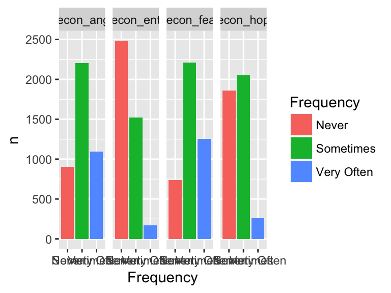

```r
#take the data frame
econ_feeling %>%
  #Gather
  gather(Emotion,Frequency) %>%
  #Filter out missing values
  na.omit() %>%
  #count
  count(Emotion, Frequency) %>%
  #plot
  ggplot(. , aes(x=Frequency, y=n, fill=Frequency))+geom_col(position='dodge')+facet_grid(~Emotion)
```

## Renaming variables

The tidyverse has an easy way to rename variables, surprise, it’s the `rename()` function.

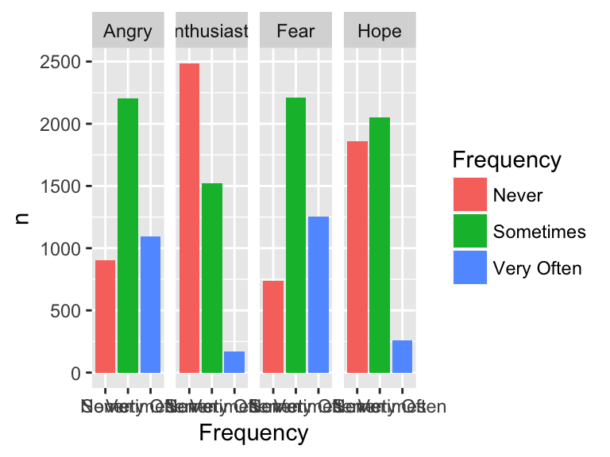

```r
#See Rename variable, store back in econ_feeling
econ_feeling<-econ_feeling %>%
  rename(., Angry=p_emecon_angr_out, Enthusiastic=p_emecon_enth_out,Fear= p_emecon_fear_out, Hope=p_emecon_hope_out)
#Replot
econ_feeling %>%
  #Gather
  gather(Emotion,Frequency) %>%
  #Filter out missing values
  na.omit() %>%
  #count
  count(Emotion, Frequency) %>%
  #plot
  ggplot(. , aes(x=Frequency, y=n, fill=Frequency))+geom_col(position='dodge')+facet_grid(~Emotion)
```

## Correlation matrices

But we might want to deal with people’s feelings about the economy by treating them as numeric. It’s dead easy using the command `cor()`

> 1. Select the economy variables using the code above. Produce a correlation matrix, using thhe command above.

```r
library(psych)
#We have the variables of interests as factors
econ_feeling %>%
  #
  mutate_all(funs(as.numeric(.))) %>%
  cor(., use='complete.obs')
```

one thing we should check is that the factor levels are in the right order.

```r
str(econ_feeling)
#Check value labels from the underlying variable
val_labels(ces_full$p_emecon_angr)
#Check levels of recoded variable
levels(econ_feeling$p_emecon_fear_out)
#Table recoded variable
table(econ_feeling$p_emecon_angr_out)
```

The `GGally` package provides a nice way of visualizing corelation matrices.

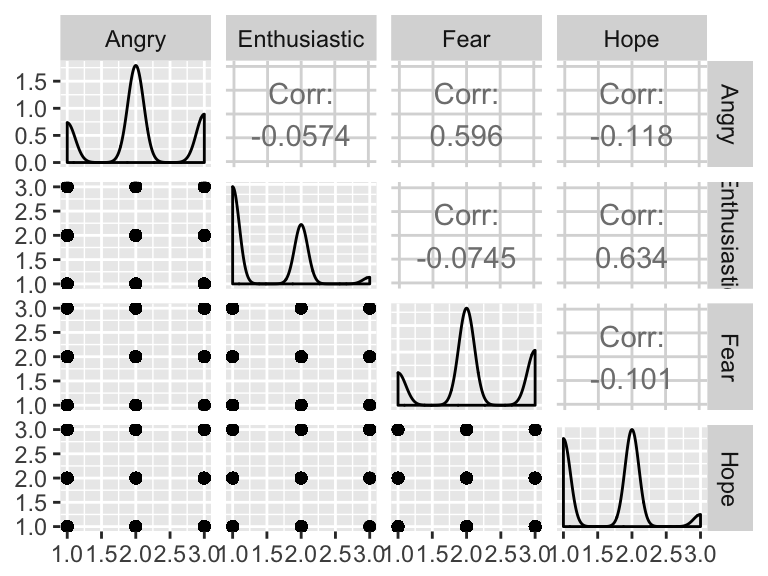

```r
#You will need to install this package
#install.packages('GGally')
#load library
library(GGally)
#Start with econ_feeling
econ_feeling %>%
  #convert to numric
  mutate_all(funs(as.numeric(.))) %>%
  ggpairs(.)
```

## Joining two data.frames

This is convenient because now we can join the two data sets and add the recoded columns to the original data frame. Or, and this would be even cooler, we can source the previous tutorial and join the two.

Notice that by sourcing this file `3_LSIRM_2018.R` we will be indirectly sourceing `2_LSIRM_2018.R` .

```r
source('https://raw.githubusercontent.com/sjkiss/LSIRM_2018/master/3_LSIRM_2018.r')
```

Notice in the environment section of RStudio, we have three dataframes `ces` with 19 variables `econ_feeling` with 4 variables and `ces_full` with 580. All have 7572 observations.

So all that recoding work that we did yesterday is not goe; we just reused it.

Now we can join `ces` from yesterday with `econ_feeling` from today using `bind_cols()`.

```r
#Take the data frame from yesterda
ces %>%
  #bind columns to it from econ_feeling
  bind_cols(., econ_feeling) -> ces
```

Now we can use all the data from the previous tutorial to analyze the new set of variables.

# Asking for help

There are tons of tutorials out there. Here are some links to some of the most useful:

1. [dplyr tutorial](http://genomicsclass.github.io/book/pages/dplyr_tutorial.html)
2. [ggplot2 tutorial](http://r-statistics.co/Complete-Ggplot2-Tutorial-Part1-With-R-Code.html)
3. [R for Data Science](http://r4ds.had.co.nz/)

The best place to ask for help is [Stackoverflow](http://www.stackoverflow.com).

A big part of asking for help on stackoverflow is to provide a reproducible example so that people can start to help you. Here are some tools to help you do that.

1. `dput()` writes out some R code that will, when others run it, reproduce your data frame exactly. This output can then be posted into a Stackexchange question, which others can then use to help solve your problem.

The downside is that when you are dealing with a large data frame (like the full `ces` data set), the content to be pasted would be too long.

```r
dput(ces[1:5,1:5])
```

2. Another option would be to recreate a simple data.frame that is smaller, but that looks conceptually just like yours and reprdocues your problem. Some tools to do this are the `rnorm()` command and the `sample()` command.
   - `rnorm()` generates a specified n random numbers from the the normal distribution with a specified mean and standard deviation.
   - But this doesn’t help us make factors. Let’s say our problem arises out of a mix of numeric and categorical variables. `sample()` draws a random sample of size `n` from a vector provided . So let’s say one of our factors has two values (like M or F) nad one of our factors has four values (say, age in 4 categories)

```r
#Make variable 1
var1<-rnorm(100, mean=5, sd=1)
```

```r
var2<-sample(c('M', 'F'), replace=T, size=100)
var3<-sample(c('young', 'old', 'older', 'oldest'), replace=T, size=100)
```

Now we have three variables and we could combine them in a data.frame.

```r
help.df<-data.frame(var1, var2, var3)
#show
str(help.df)
```

We could paste the above code, then we could paste the code that creates our problem. Anyone could reproduce your problem, wihtout trading huge data files and provide you with a solution.

See also [this question](https://stackoverflow.com/questions/5963269/how-to-make-a-great-r-reproducible-example?rq=1) on Stackoverflow.

# Reporting Results (RMarkdown)